# Latihan 1 Shira Pramudita

## Single Moving Average & Double Moving Average

### Pembagian Data

Pembagian data latih dan data uji dilakukan dengan perbandingan 80% data latih dan 20% data uji.

```r
# hitung jumlah data
n <- nrow(data)

# tentukan batas 80%
n_train <- floor(0.8 * n)

# bagi data
training_ma <- data[1:n_train, ]
testing_ma  <- data[(n_train + 1):n, ]

# ubah ke time series
train_ma.ts <- ts(training_ma$Beban)
test_ma.ts  <- ts(testing_ma$Beban)

cat("Data latih :", nrow(training_ma), "observasi\n")
```

```
## Data latih : 1460 observasi
```

```r
cat("Data uji   :", nrow(testing_ma), "observasi\n")
```

```
## Data uji   : 366 observasi
```

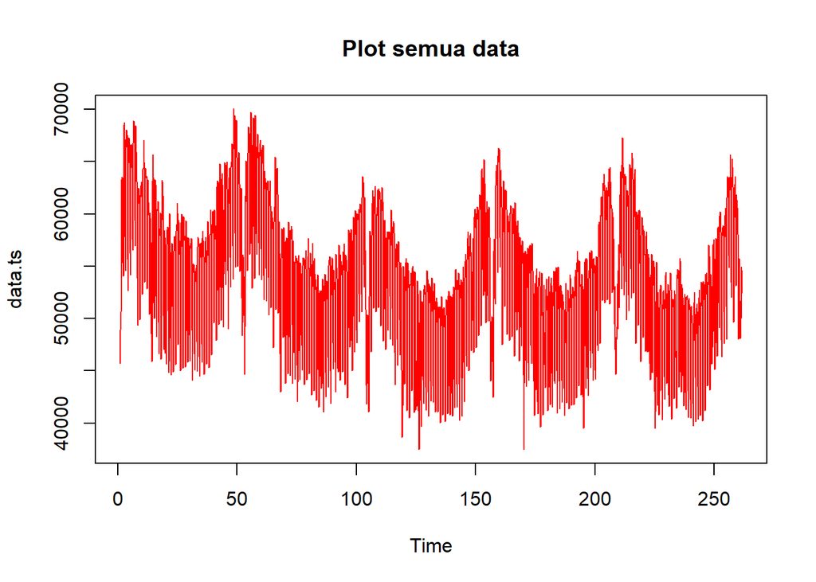

```r
#eksplorasi keseluruhan data
plot(data.ts, col = "red", main = "Plot semua data")
```

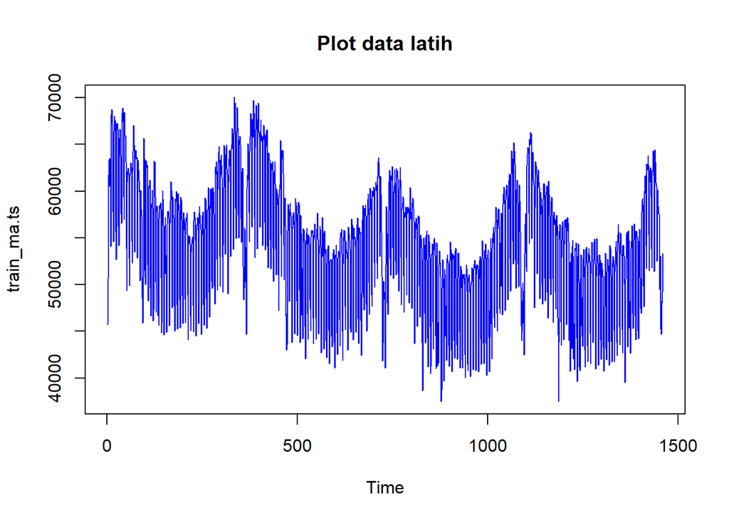

```r
#eksplorasi data latih
plot(train_ma.ts, col = "blue", main = "Plot data latih")
```

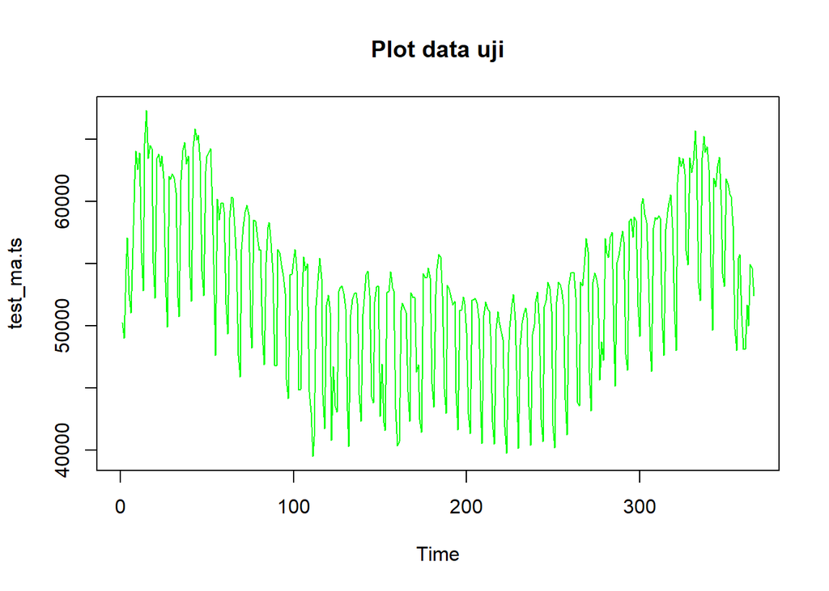

```r
#eksplorasi data uji
plot(test_ma.ts, col = "green", main = "Plot data uji")
```

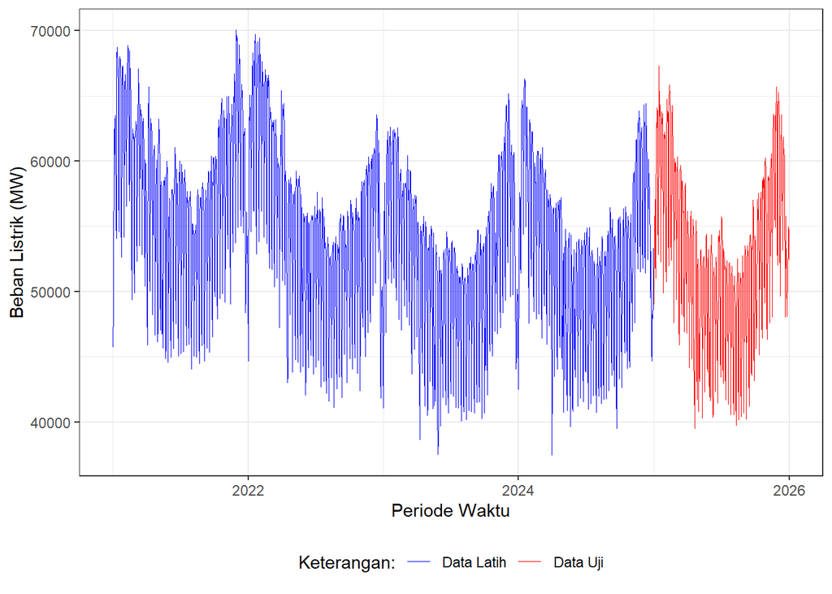

```r
ggplot() +
  geom_line(data = training_ma, aes(x = Tanggal, y = Beban, col = "Data Latih"), linewidth = 0.3) +
  geom_line(data = testing_ma, aes(x = Tanggal, y = Beban, col = "Data Uji"), linewidth = 0.3) +
  labs(x = "Periode Waktu", y = "Beban Listrik (MW)", color = "Legend") +
  scale_colour_manual(name = "Keterangan:", breaks = c("Data Latih", "Data Uji"),
                      values = c("blue", "red")) +
  theme_bw() + theme(legend.position = "bottom",
                     plot.caption = element_text(hjust = 0.5, size = 12))
```

### Single Moving Average (SMA)

Ide dasar dari Single Moving Average (SMA) adalah data suatu periode dipengaruhi oleh data periode sebelumnya. Metode pemulusan ini cocok digunakan untuk pola data stasioner atau konstan. Prinsip dasarnya adalah data pemulusan pada periode ke-$t$ merupakan rata-rata dari $m$ buah data pada periode ke-$t$ hingga periode ke-$(t-m+1)$.

$$S_t = \frac{1}{m}\sum_{i=t-m+1}^{t} X_i$$

Rentang $m = 7$ dipilih agar sesuai dengan panjang siklus mingguan data.

```r
data.sma <- SMA(train_ma.ts, n = 7)
head(data.sma, 10)
```

```
## Time Series:
## Start = 1
## End = 10
## Frequency = 1
##  [1]       NA       NA       NA       NA       NA       NA 56330.88 58738.10
##  [9] 59656.78 60142.49
```

Nilai pemulusan pada periode ke-$t$ berperan sebagai nilai ramalan pada periode ke-$(t+1)$.

```r
data.ramal <- c(NA, data.sma)
head(cbind(aktual = c(train_ma.ts, NA),
           pemulusan = c(data.sma, NA),
           ramalan = c(data.ramal, NA)), 10)
```

```
##         aktual pemulusan  ramalan
##  [1,] 45716.98        NA       NA
##  [2,] 48891.70        NA       NA
##  [3,] 50646.64        NA       NA
##  [4,] 61715.99        NA       NA
##  [5,] 63290.04        NA       NA
##  [6,] 60523.86        NA       NA
##  [7,] 63530.96  56330.88       NA
##  [8,] 62567.52  58738.10 56330.88
##  [9,] 55322.42  59656.78 58738.10
## [10,] 54046.64  60142.49 59656.78
```

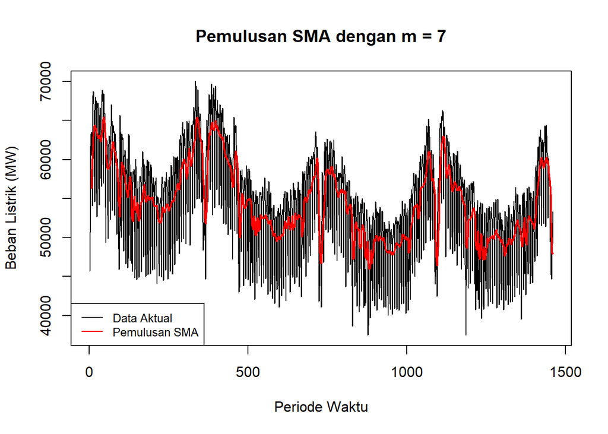

```r
ts.plot(train_ma.ts, xlab = "Periode Waktu", ylab = "Beban Listrik (MW)",
        col = "black", main = "Pemulusan SMA dengan m = 7")
lines(data.sma, col = "red", lwd = 2)
legend("bottomleft", legend = c("Data Aktual", "Pemulusan SMA"),
       col = c("black", "red"), lty = 1, cex = 0.8)
```

Selanjutnya dihitung nilai keakuratan pada data latih. Ukuran yang digunakan adalah SSE, MSE, dan MAPE.

$$MAPE = \frac{1}{n}\sum_{t=1}^{n}\left|\frac{y_t - \hat{y}_t}{y_t}\right|
\times 100\%$$

```r
#Menghitung nilai keakuratan data latih
error_train.sma <- train_ma.ts - data.ramal[1:length(train_ma.ts)]

SSE_train.sma  <- sum(error_train.sma[8:length(train_ma.ts)]^2)
MSE_train.sma  <- mean(error_train.sma[8:length(train_ma.ts)]^2)
MAPE_train.sma <- mean(abs((error_train.sma[8:length(train_ma.ts)] /
                              train_ma.ts[8:length(train_ma.ts)]) * 100))

akurasi_train.sma <- matrix(c(SSE_train.sma, MSE_train.sma, MAPE_train.sma))
row.names(akurasi_train.sma) <- c("SSE", "MSE", "MAPE")
colnames(akurasi_train.sma)  <- c("Akurasi m = 7")
akurasi_train.sma
```

```
##      Akurasi m = 7
## SSE   3.746803e+10
## MSE   2.578667e+07
## MAPE  8.450040e+00
```

```r
#Menghitung nilai keakuratan data uji
ramalan_sma <- rep(tail(data.sma[!is.na(data.sma)], 1), length(test_ma.ts))
error_test.sma <- test_ma.ts - ramalan_sma

SSE_test.sma  <- sum(error_test.sma^2)
MSE_test.sma  <- mean(error_test.sma^2)
MAPE_test.sma <- mean(abs(error_test.sma / test_ma.ts * 100))

akurasi_test.sma <- matrix(c(SSE_test.sma, MSE_test.sma, MAPE_test.sma))
row.names(akurasi_test.sma) <- c("SSE", "MSE", "MAPE")
colnames(akurasi_test.sma)  <- c("Akurasi m = 7")
akurasi_test.sma
```

```
##      Akurasi m = 7
## SSE   2.517810e+10
## MSE   6.879261e+07
## MAPE  1.253898e+01
```

### Double Moving Average (DMA)

Metode DMA pada dasarnya mirip dengan SMA, hanya saja proses perataan dilakukan dua kali. Metode ini lebih sesuai untuk data yang berpola tren.

$$S_{1,t} = \frac{1}{m}\sum_{i=t-m+1}^{t} X_i \qquad
S_{2,t} = \frac{1}{m}\sum_{i=t-m+1}^{t} S_{1,i}$$

$$A_t = 2S_{1,t} - S_{2,t} \qquad
B_t = \frac{2}{m-1}(S_{1,t} - S_{2,t}) \qquad
F_{t+h} = A_t + B_t h$$

```r
dma <- SMA(data.sma, n = 7)
At <- 2 * data.sma - dma
Bt <- (2 / (7 - 1)) * (data.sma - dma)
data.dma <- At + Bt
data.ramal2 <- c(NA, data.dma)
head(cbind(SMA = data.sma, DMA = dma, At = At, Bt = Bt, Pemulusan = data.dma), 16)
```

```
## Time Series:
## Start = 1
## End = 16
## Frequency = 1
##         SMA      DMA       At       Bt Pemulusan
##  1       NA       NA       NA       NA        NA
##  2       NA       NA       NA       NA        NA
##  3       NA       NA       NA       NA        NA
##  4       NA       NA       NA       NA        NA
##  5       NA       NA       NA       NA        NA
##  6       NA       NA       NA       NA        NA
##  7 56330.88       NA       NA       NA        NA
##  8 58738.10       NA       NA       NA        NA
##  9 59656.78       NA       NA       NA        NA
## 10 60142.49       NA       NA       NA        NA
## 11 61066.89       NA       NA       NA        NA
## 12 61808.72       NA       NA       NA        NA
## 13 62981.70 60103.65 65859.75 959.3500  66819.10
## 14 63501.21 61127.98 65874.44 791.0765  66665.52
## 15 63948.73 61872.36 66025.11 692.1241  66717.23
## 16 64308.49 62536.89 66080.09 590.5333  66670.62
```

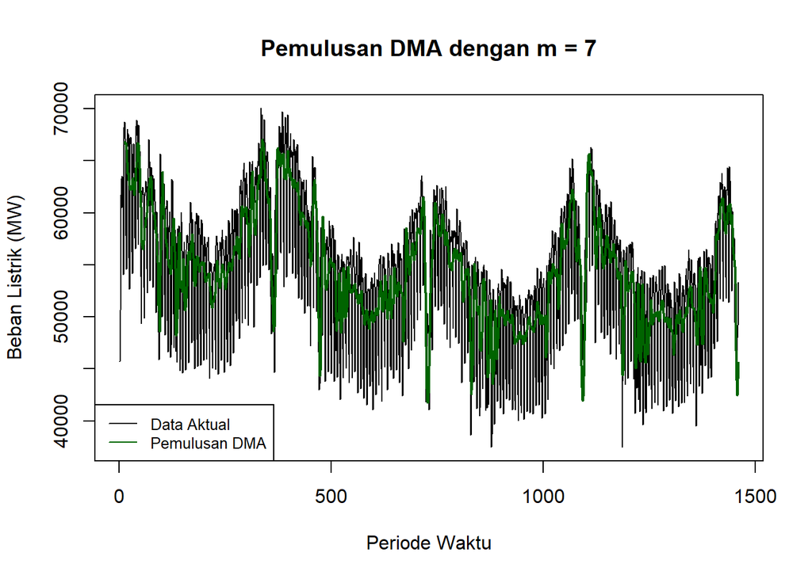

```r
ts.plot(train_ma.ts, xlab = "Periode Waktu", ylab = "Beban Listrik (MW)",
        col = "black", main = "Pemulusan DMA dengan m = 7")
lines(data.dma, col = "darkgreen", lwd = 2)
legend("bottomleft", legend = c("Data Aktual", "Pemulusan DMA"),
       col = c("black", "darkgreen"), lty = 1, cex = 0.8)
```

```r
#Menghitung nilai keakuratan data latih
error_train.dma <- train_ma.ts - data.ramal2[1:length(train_ma.ts)]

SSE_train.dma  <- sum(error_train.dma[15:length(train_ma.ts)]^2)
MSE_train.dma  <- mean(error_train.dma[15:length(train_ma.ts)]^2)
MAPE_train.dma <- mean(abs((error_train.dma[15:length(train_ma.ts)] /
                              train_ma.ts[15:length(train_ma.ts)]) * 100))

akurasi_train.dma <- matrix(c(SSE_train.dma, MSE_train.dma, MAPE_train.dma))
row.names(akurasi_train.dma) <- c("SSE", "MSE", "MAPE")
colnames(akurasi_train.dma)  <- c("Akurasi m = 7")
akurasi_train.dma
```

```
##      Akurasi m = 7
## SSE   3.846643e+10
## MSE   2.660196e+07
## MAPE  8.367314e+00
```

```r
#Menghitung nilai keakuratan data uji
h <- length(test_ma.ts)
i <- length(train_ma.ts)
ramalan_dma <- At[i] + Bt[i] * (1:h)
error_test.dma <- test_ma.ts - ramalan_dma

SSE_test.dma  <- sum(error_test.dma^2)
MSE_test.dma  <- mean(error_test.dma^2)
MAPE_test.dma <- mean(abs(error_test.dma / test_ma.ts * 100))

akurasi_test.dma <- matrix(c(SSE_test.dma, MSE_test.dma, MAPE_test.dma))
row.names(akurasi_test.dma) <- c("SSE", "MSE", "MAPE")
colnames(akurasi_test.dma)  <- c("Akurasi m = 7")
akurasi_test.dma
```

```
##      Akurasi m = 7
## SSE   6.240073e+12
## MSE   1.704938e+10
## MAPE  2.189574e+02
```

Perbandingan SMA dan DMA pada data uji ditampilkan berikut.

```r
data.frame(Metode = c("SMA (m=7)", "DMA (m=7)"),
           SSE  = c(SSE_test.sma, SSE_test.dma),
           MSE  = c(MSE_test.sma, MSE_test.dma),
           MAPE = c(MAPE_test.sma, MAPE_test.dma))
```

```
##      Metode          SSE         MSE      MAPE
## 1 SMA (m=7) 2.517810e+10    68792612  12.53898
## 2 DMA (m=7) 6.240073e+12 17049378636 218.95737
```

## Single Exponential Smoothing & Double Exponential Smoothing

### Pembagian Data

```r
# jumlah baris data
n <- nrow(data)

# hitung batas 80%
n_train <- floor(0.8 * n)

# bagi data
training <- data[1:n_train, ]
testing  <- data[(n_train + 1):n, ]

# ubah ke time series
train.ts <- ts(training$Beban)
test.ts  <- ts(testing$Beban)
```

### Eksplorasi

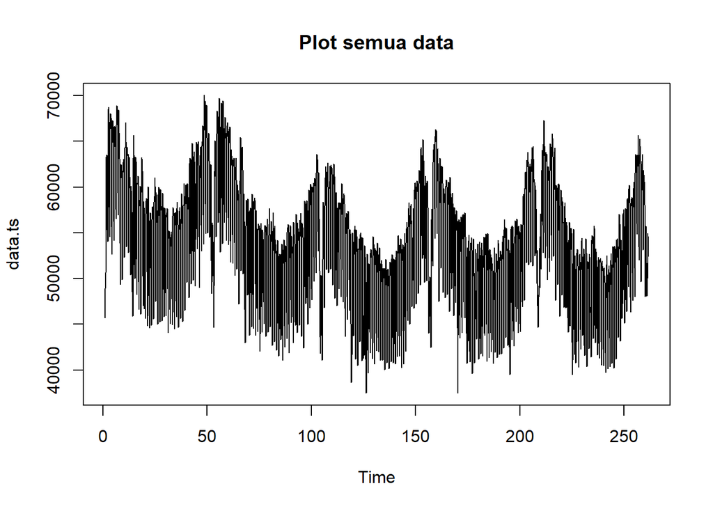

```r
#eksplorasi data
plot(data.ts, col = "black", main = "Plot semua data")
```

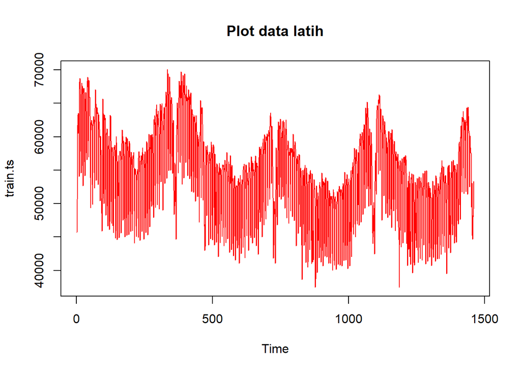

```r
plot(train.ts, col = "red", main = "Plot data latih")
```

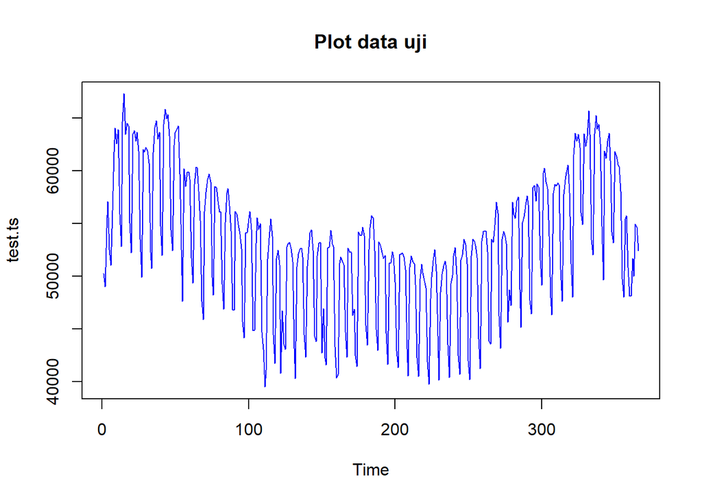

```r
plot(test.ts, col = "blue", main = "Plot data uji")
```

## Single Exponential Smoothing

Metode pemulusan eksponensial memberikan bobot yang menurun secara eksponensial terhadap pengamatan yang lebih lama.

$$S_t = \lambda X_t + (1 - \lambda) S_{t-1}, \qquad 0 < \lambda < 1$$

Pemulusan dilakukan dengan dua nilai $\lambda$, yaitu 0,2 dan 0,7, kemudian dibandingkan dengan nilai $\lambda$ optimum.

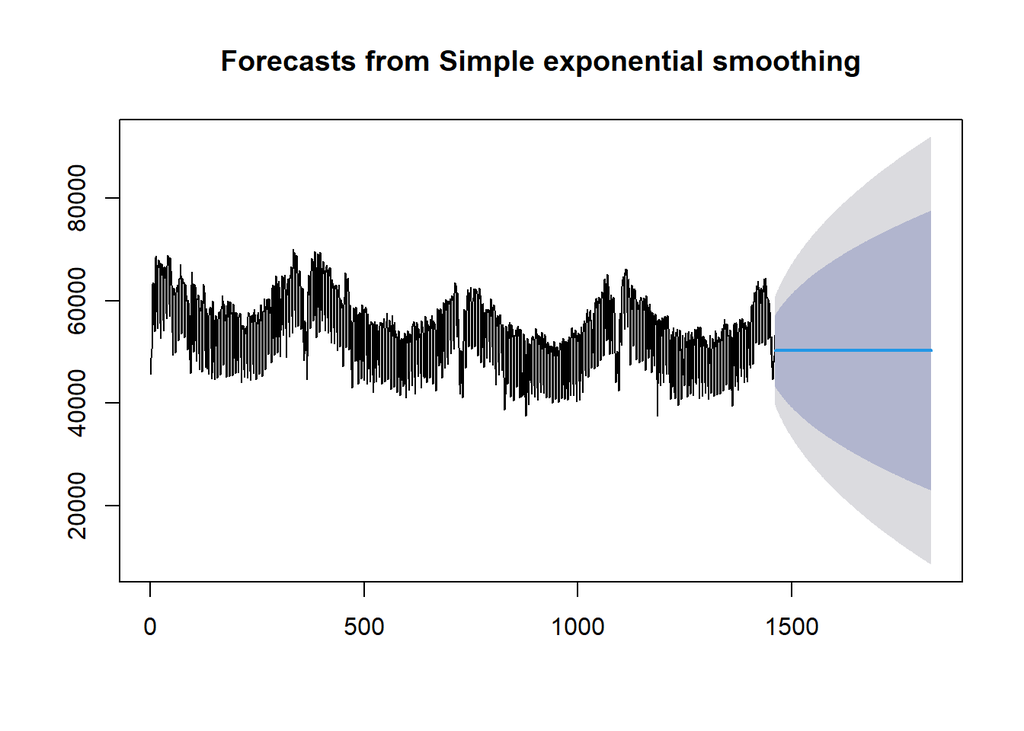

```r
#Cara 1 (fungsi ses)
ses.1 <- ses(train.ts, h = length(test.ts), alpha = 0.2)
plot(ses.1)
```

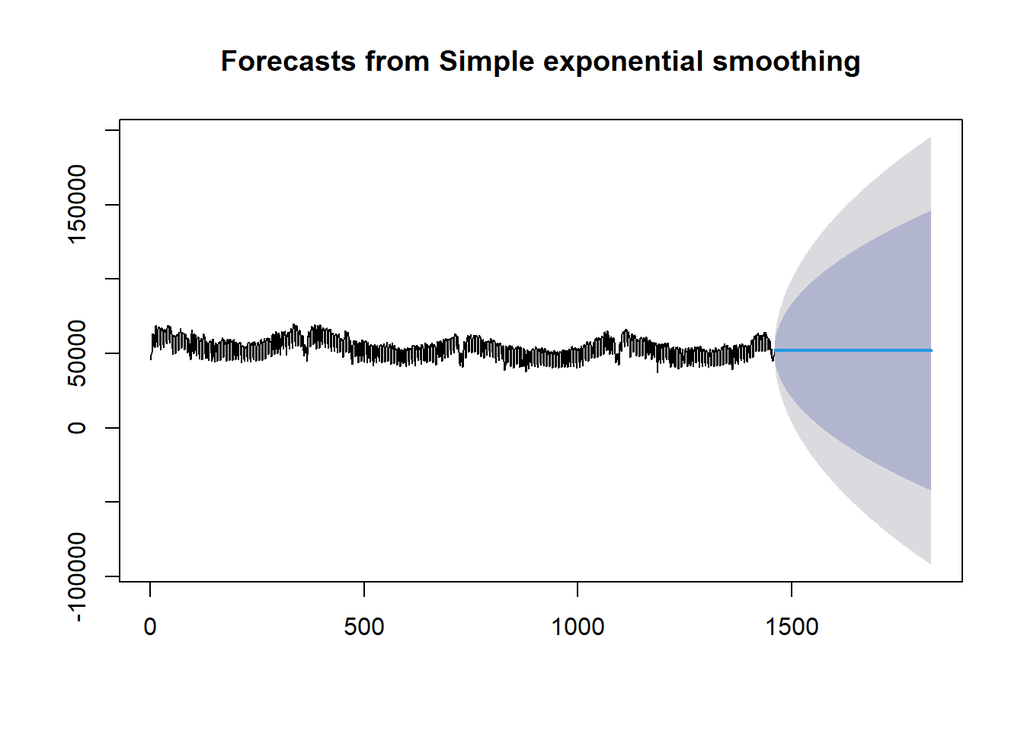

```r
ses.2 <- ses(train.ts, h = length(test.ts), alpha = 0.7)
plot(ses.2)
```

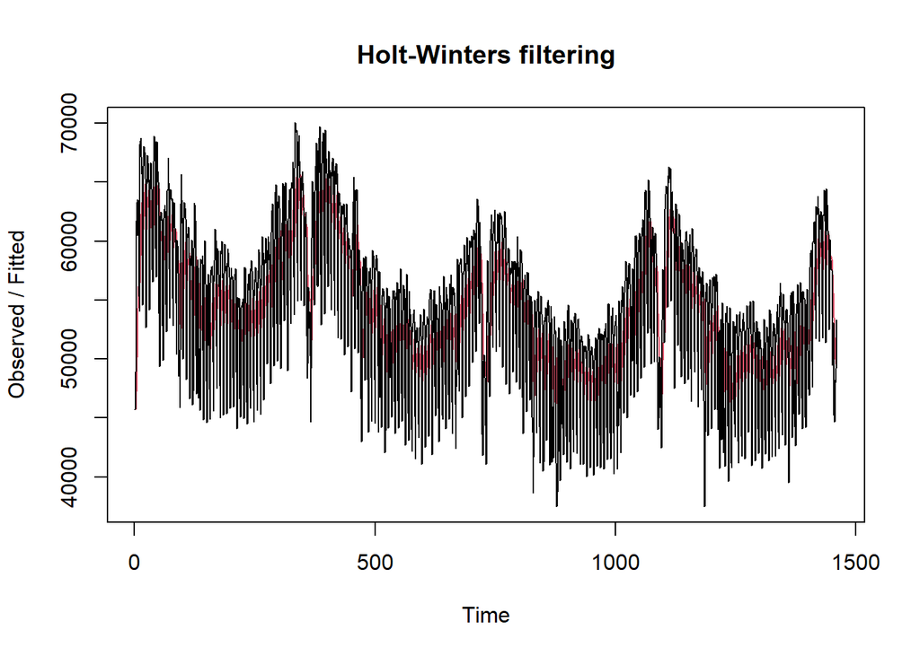

```r
#Cara 2 (fungsi HoltWinters)
ses1 <- HoltWinters(train.ts, gamma = FALSE, beta = FALSE, alpha = 0.2)
plot(ses1)
```

```r
#ramalan
ramalan1 <- forecast(ses1, h = length(test.ts))
head(ramalan1$mean)
```

```
## Time Series:
## Start = 1461
## End = 1466
## Frequency = 1
## [1] 50267.46 50267.46 50267.46 50267.46 50267.46 50267.46
```

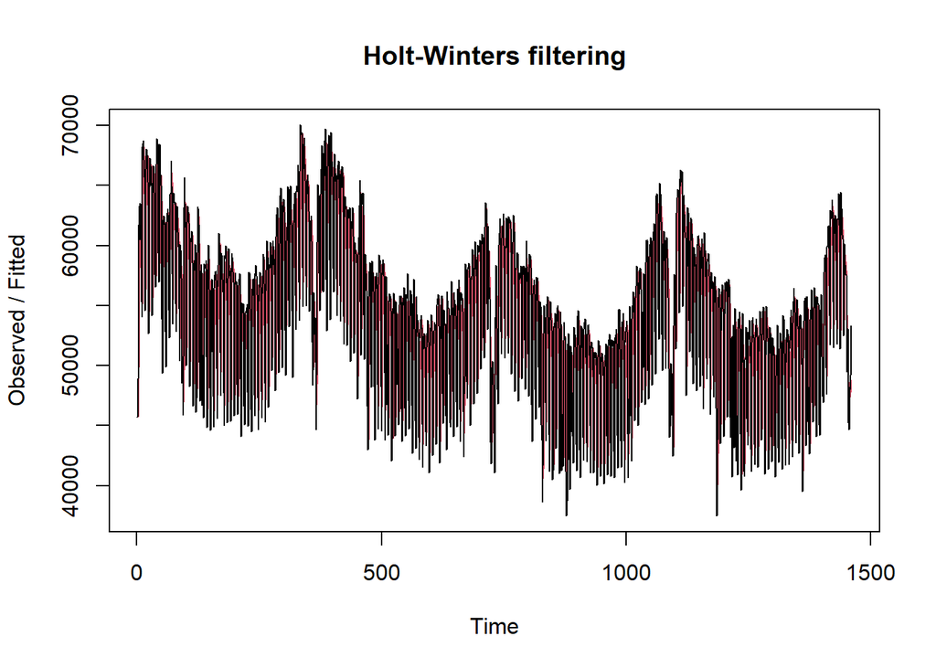

```r
ses2 <- HoltWinters(train.ts, gamma = FALSE, beta = FALSE, alpha = 0.7)
plot(ses2)
```

```r
#ramalan
ramalan2 <- forecast(ses2, h = length(test.ts))
head(ramalan2$mean)
```

```
## Time Series:
## Start = 1461
## End = 1466
## Frequency = 1
## [1] 51932.53 51932.53 51932.53 51932.53 51932.53 51932.53
```

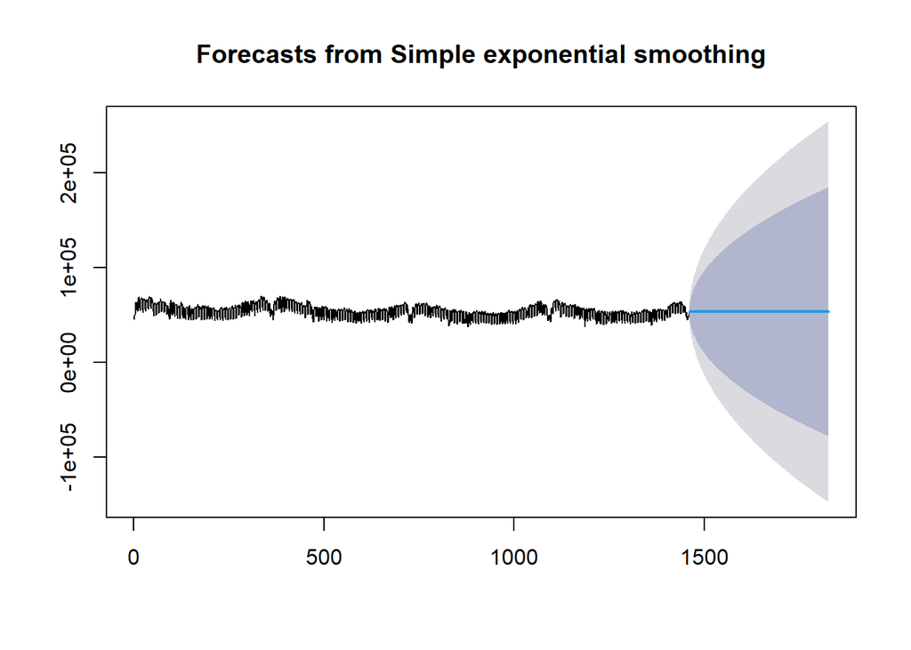

```r
#Lamda Optimum
ses.opt <- ses(train.ts, h = length(test.ts), alpha = NULL)
plot(ses.opt)
```

```r
#Lamda optimum
ses.opt$model$par["alpha"]
```

```
##  alpha
## 0.9999
```

#### Akurasi Data Latih

```r
# SES dengan alpha = 0.2
SSE1 <- ses1$SSE
MSE1 <- ses1$SSE / length(train.ts)
RMSE1 <- sqrt(MSE1)
akurasi1 <- matrix(c(SSE1, MSE1, RMSE1))
row.names(akurasi1) <- c("SSE", "MSE", "RMSE")
colnames(akurasi1) <- c("Akurasi lamda=0.2")
akurasi1
```

```
##      Akurasi lamda=0.2
## SSE       4.267200e+10
## MSE       2.922739e+07
## RMSE      5.406237e+03
```

```r
# SES dengan alpha = 0.7
SSE2 <- ses2$SSE
MSE2 <- ses2$SSE / length(train.ts)
RMSE2 <- sqrt(MSE2)
akurasi2 <- matrix(c(SSE2, MSE2, RMSE2))
row.names(akurasi2) <- c("SSE", "MSE", "RMSE")
colnames(akurasi2) <- c("Akurasi lamda=0.7")
akurasi2
```

```
##      Akurasi lamda=0.7
## SSE       4.365858e+10
## MSE       2.990314e+07
## RMSE      5.468376e+03
```

```r
#Cara Manual
# Alpha = 0.2
sisaan1 <- ramalan1$residuals

SSE.1 <- sum(sisaan1[3:length(train.ts)]^2)
MSE.1 <- SSE.1 / length(train.ts)
MAPE.1 <- sum(abs(sisaan1[3:length(train.ts)] / train.ts[3:length(train.ts)])) *
  100 / length(train.ts)

akurasi.1 <- matrix(c(SSE.1, MSE.1, MAPE.1))
row.names(akurasi.1) <- c("SSE", "MSE", "MAPE")
colnames(akurasi.1) <- c("Akurasi lamda=0.2")
akurasi.1
```

```
##      Akurasi lamda=0.2
## SSE       4.266192e+10
## MSE       2.922049e+07
## MAPE      9.070295e+00
```

```r
# Alpha = 0.7
sisaan2 <- ramalan2$residuals

SSE.2 <- sum(sisaan2[3:length(train.ts)]^2)
MSE.2 <- SSE.2 / length(train.ts)
MAPE.2 <- sum(abs(sisaan2[3:length(train.ts)] / train.ts[3:length(train.ts)])) *
  100 / length(train.ts)

akurasi.2 <- matrix(c(SSE.2, MSE.2, MAPE.2))
row.names(akurasi.2) <- c("SSE", "MSE", "MAPE")
colnames(akurasi.2) <- c("Akurasi lamda=0.7")
akurasi.2
```

```
##      Akurasi lamda=0.7
## SSE       4.364850e+10
## MSE       2.989623e+07
## MAPE      8.261596e+00
```

#### Akurasi Data Uji

```r
# error (aktual - ramalan)
e1 <- as.numeric(test.ts) - as.numeric(ramalan1$mean)
e2 <- as.numeric(test.ts) - as.numeric(ramalan2$mean)
e3 <- as.numeric(test.ts) - as.numeric(ses.opt$mean)

# fungsi ringkas SSE / MSE / RMSE / MAPE
hitung <- function(e, aktual) {
  c(SSE = sum(e^2), MSE = mean(e^2), RMSE = sqrt(mean(e^2)),
    MAPE = mean(abs(e / aktual)) * 100)
}

# Tabel ringkas
akurasi_ses_test <- rbind(
  `lamda = 0.2`   = hitung(e1, as.numeric(test.ts)),
  `lamda = 0.7`   = hitung(e2, as.numeric(test.ts)),
  `lamda optimum` = hitung(e3, as.numeric(test.ts))
)
round(akurasi_ses_test, 3)
```

```
##                       SSE      MSE     RMSE   MAPE
## lamda = 0.2   18341084654 50112253 7079.001 10.644
## lamda = 0.7   15820371923 43225060 6574.577  9.844
## lamda optimum 15266858077 41712727 6458.539  9.919
```

## *Double Exponential Smoothing* (DES)

DES melakukan pemulusan dua tahap, yaitu untuk komponen aras (*level*) dan komponen tren.

$$S_t = \lambda X_t + (1-\lambda)(S_{t-1} + b_{t-1})$$

$$b_t = \gamma (S_t - S_{t-1}) + (1 - \gamma) b_{t-1}$$

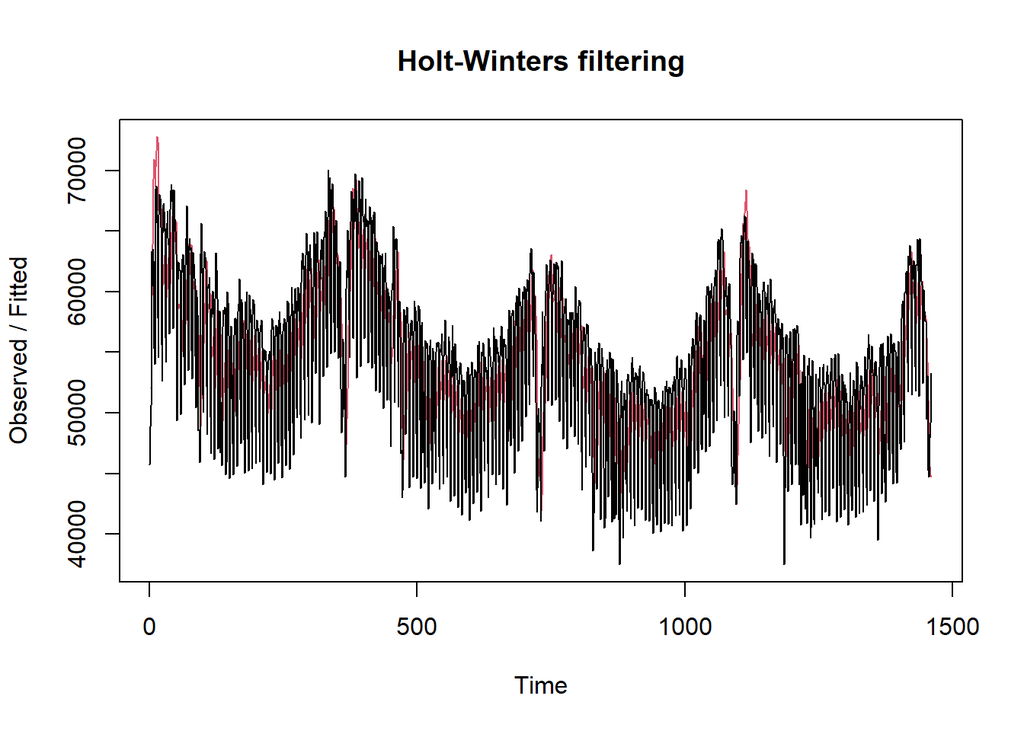

```r
#Lamda=0.2 dan gamma=0.2
des.1 <- HoltWinters(train.ts, gamma = FALSE, beta = 0.2, alpha = 0.2)
plot(des.1)
```

```r
#ramalan
ramalandes1 <- forecast(des.1, h = length(test.ts))
head(ramalandes1$mean)
```

```
## Time Series:
## Start = 1461
## End = 1466
## Frequency = 1
## [1] 45772.20 45096.61 44421.02 43745.43 43069.84 42394.25
```

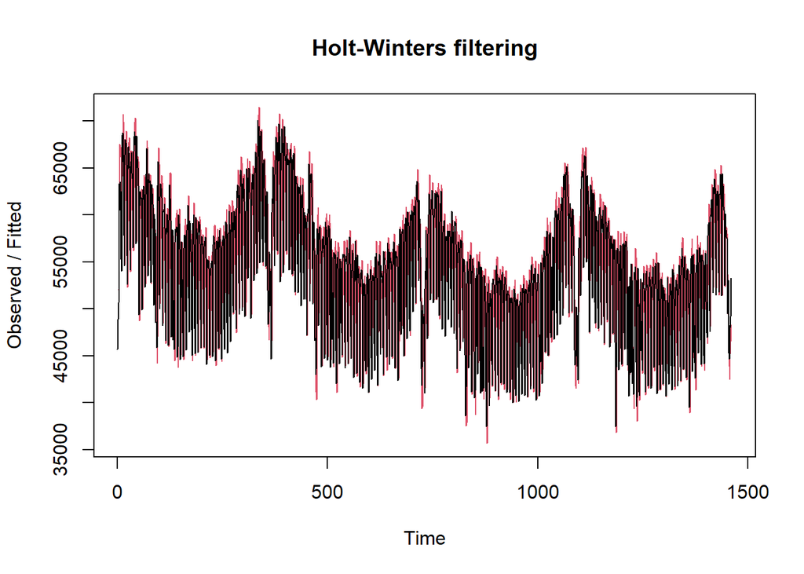

```r
#Lamda=0.6 dan gamma=0.3
des.2 <- HoltWinters(train.ts, gamma = FALSE, beta = 0.3, alpha = 0.6)
plot(des.2)
```

```r
#ramalan
ramalandes2 <- forecast(des.2, h = length(test.ts))
head(ramalandes2$mean)
```

```
## Time Series:
## Start = 1461
## End = 1466
## Frequency = 1
## [1] 52370.66 53444.46 54518.27 55592.08 56665.89 57739.70
```

```r
#Nilai parameter optimum
des.opt <- HoltWinters(train.ts, gamma = FALSE)
des.opt
```

```
## Holt-Winters exponential smoothing with trend and without seasonal component.
##
## Call:
## HoltWinters(x = train.ts, gamma = FALSE)
##
## Smoothing parameters:
##  alpha: 0.2312453
##  beta : 0.05992253
##  gamma: FALSE
##
## Coefficients:
##         [,1]
## a 48668.1517
## b  -409.9643
```

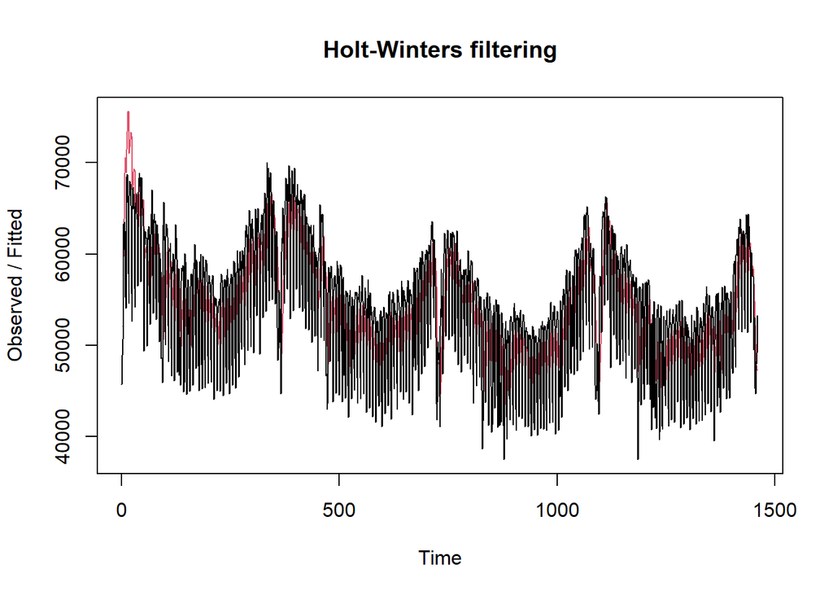

```r
plot(des.opt)
```

```r
#ramalan
ramalandesopt <- forecast(des.opt, h = length(test.ts))
head(ramalandesopt$mean)
```

```
## Time Series:
## Start = 1461
## End = 1466
## Frequency = 1
## [1] 48258.19 47848.22 47438.26 47028.29 46618.33 46208.37
```

#### Akurasi Data Latih

```r
#Akurasi Data Training
ssedes.train1 <- des.1$SSE
msedes.train1 <- ssedes.train1 / length(train.ts)
sisaandes1 <- ramalandes1$residuals
mapedes.train1 <- sum(abs(sisaandes1[3:length(train.ts)] /
                            train.ts[3:length(train.ts)])) * 100 / length(train.ts)

akurasides.1 <- matrix(c(ssedes.train1, msedes.train1, mapedes.train1))
row.names(akurasides.1) <- c("SSE", "MSE", "MAPE")
colnames(akurasides.1) <- c("Akurasi lamda=0.2 dan gamma=0.2")
akurasides.1
```

```
##      Akurasi lamda=0.2 dan gamma=0.2
## SSE                     4.759868e+10
## MSE                     3.260184e+07
## MAPE                    9.393247e+00
```

```r
ssedes.train2 <- des.2$SSE
msedes.train2 <- ssedes.train2 / length(train.ts)
sisaandes2 <- ramalandes2$residuals
mapedes.train2 <- sum(abs(sisaandes2[3:length(train.ts)] /
                            train.ts[3:length(train.ts)])) * 100 / length(train.ts)

akurasides.2 <- matrix(c(ssedes.train2, msedes.train2, mapedes.train2))
row.names(akurasides.2) <- c("SSE", "MSE", "MAPE")
colnames(akurasides.2) <- c("Akurasi lamda=0.6 dan gamma=0.3")
akurasides.2
```

```
##      Akurasi lamda=0.6 dan gamma=0.3
## SSE                     5.966604e+10
## MSE                     4.086715e+07
## MAPE                    9.807882e+00
```

#### Akurasi Data Uji

```r
ed1 <- as.numeric(test.ts) - as.numeric(ramalandes1$mean)
ed2 <- as.numeric(test.ts) - as.numeric(ramalandes2$mean)
ed3 <- as.numeric(test.ts) - as.numeric(ramalandesopt$mean)

akurasi_des_test <- rbind(
  `lamda=0.2 gamma=0.2` = hitung(ed1, as.numeric(test.ts)),
  `lamda=0.6 gamma=0.3` = hitung(ed2, as.numeric(test.ts)),
  `parameter optimum`   = hitung(ed3, as.numeric(test.ts))
)
round(akurasi_des_test, 3)
```

```
##                              SSE         MSE      RMSE    MAPE
## lamda=0.2 gamma=0.2 8.104046e+12 22142203282 148802.57 249.209
## lamda=0.6 gamma=0.3 1.871150e+13 51124304836 226106.84 376.199
## parameter optimum   3.011869e+12  8229150218  90714.66 151.424
```

#### Perbandingan SES dan DES

```r
perbandingan <- rbind(
  `SES optimum` = hitung(e3, as.numeric(test.ts)),
  `DES optimum` = hitung(ed3, as.numeric(test.ts))
)
round(perbandingan, 3)
```

```
##                      SSE        MSE      RMSE    MAPE
## SES optimum 1.526686e+10   41712727  6458.539   9.919
## DES optimum 3.011869e+12 8229150218 90714.664 151.424
```

```r
if (perbandingan["SES optimum", "MAPE"] < perbandingan["DES optimum", "MAPE"]) {
  cat("Metode SES lebih baik dibandingkan DES pada data ini.\n")
} else {
  cat("Metode DES lebih baik dibandingkan SES pada data ini.\n")
}
```

```
## Metode SES lebih baik dibandingkan DES pada data ini.
```

## Pemulusan Data Musiman

Bagian ini menggunakan data yang sama, tetapi objek deret waktunya dibentuk dengan `frequency = 7` agar komponen musiman mingguan dapat dimodelkan.

```r
#membagi data menjadi training dan testing
training.ts <- ts(training$Beban, frequency = 7)
testing.ts  <- ts(testing$Beban, frequency = 7)
```

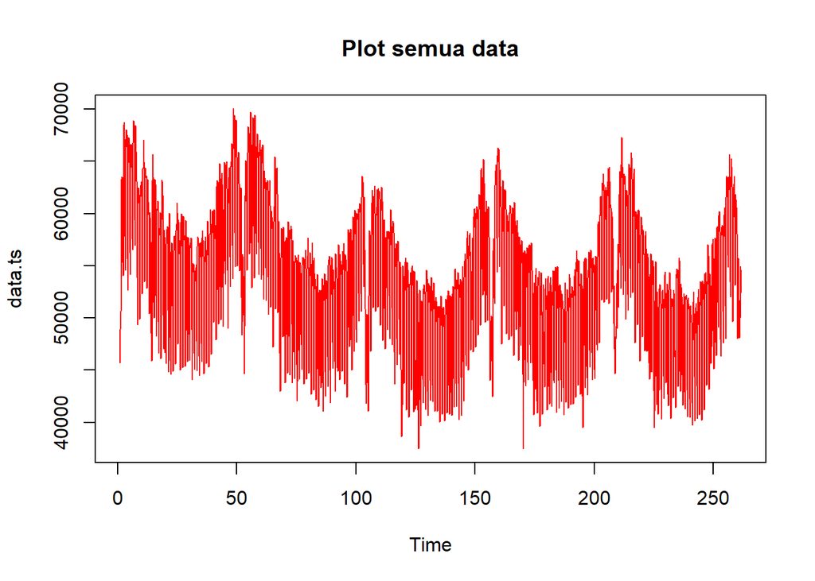

```r
#Membuat plot time series
plot(data.ts, col = "red", main = "Plot semua data")
```

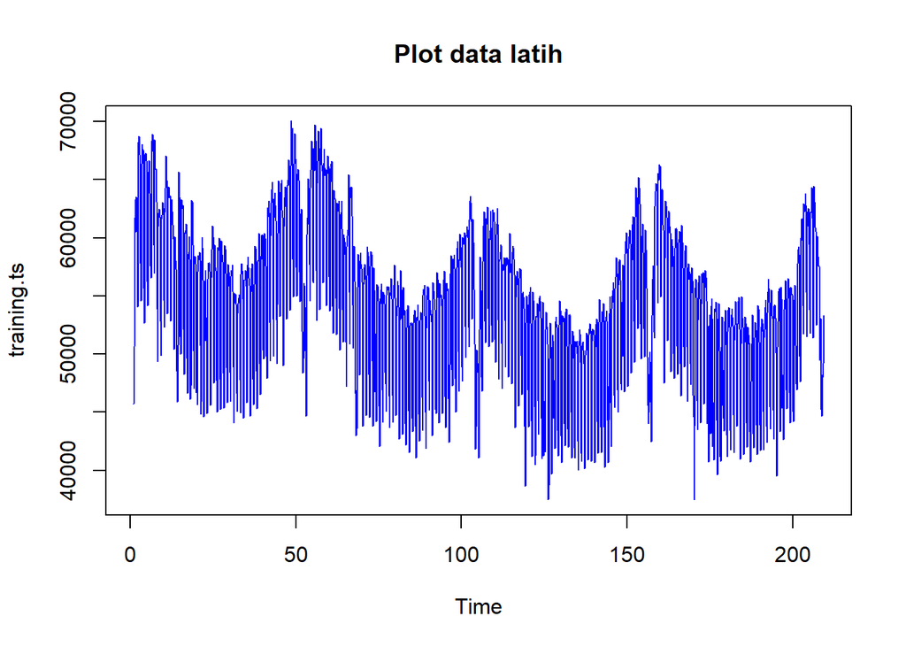

```r
plot(training.ts, col = "blue", main = "Plot data latih")
```

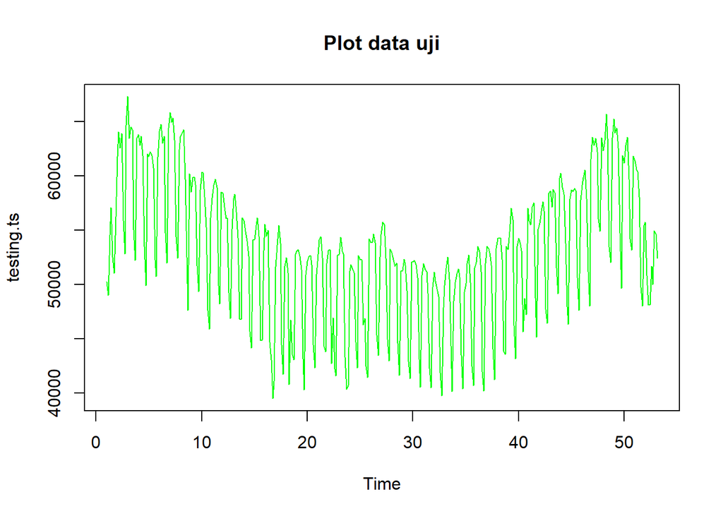

```r
plot(testing.ts, col = "green", main = "Plot data uji")
```

Metode Holt-Winter untuk peramalan data musiman menggunakan tiga persamaan pemulusan yang terdiri atas persamaan untuk level $(L_t)$, trend $(B_t)$, dan komponen seasonal/musiman $(S_t)$ dengan parameter pemulusan berupa $\alpha$, $\beta$, dan $\gamma$. Metode Holt-Winter musiman terbagi menjadi dua, yaitu metode aditif dan metode multiplikatif.

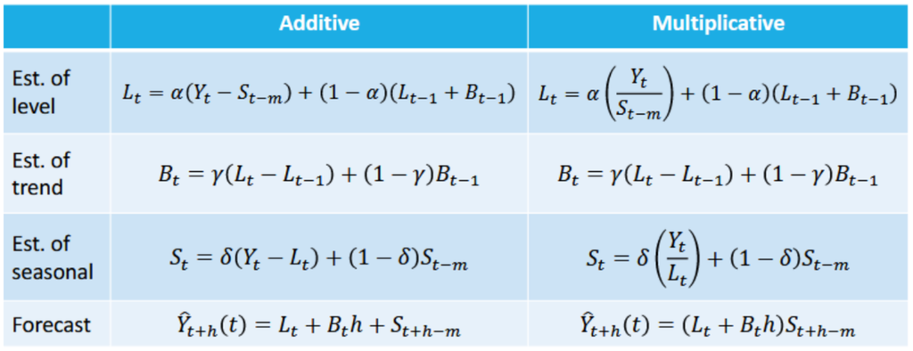

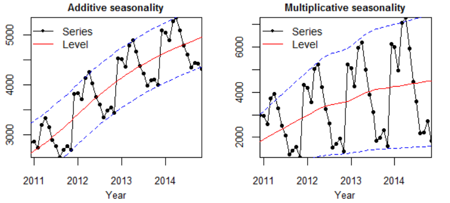

Pemulusan data musiman dengan metode Winter dilakukan menggunakan fungsi `HoltWinters()` dengan memasukkan argumen tambahan, yaitu `gamma()` dan `seasonal()`. Argumen `seasonal()` diinisialisasi menyesuaikan jenis musiman, aditif atau multiplikatif.

### Winter Aditif

Perhitungan dengan model aditif dilakukan jika plot data asli menunjukkan fluktuasi musiman yang relatif stabil (konstan).

#### Pemulusan

```r
#Pemulusan dengan winter aditif
winter1 <- HoltWinters(training.ts, alpha = 0.2, beta = 0.1, gamma = 0.1,
                       seasonal = "additive")
head(winter1$fitted)
```

```
## Time Series:
## Start = c(2, 1)
## End = c(2, 6)
## Frequency = 7
##              xhat    level     trend     season
## 2.000000 58757.16 56307.42  937.9828  1511.7516
## 2.142857 52546.50 58007.48 1014.1900 -6475.1698
## 2.285714 51722.63 59576.85 1069.7084 -8923.9355
## 2.428571 67274.04 61111.36 1116.1887  5046.4831
## 2.571429 68107.62 62410.11 1134.4444  4563.0645
## 2.714286 65639.75 63619.59 1141.9478   878.2102
```

```r
xhat1 <- winter1$fitted[, 2]

winter1.opt <- HoltWinters(training.ts, alpha = NULL, beta = NULL, gamma = NULL,
                           seasonal = "additive")
winter1.opt
```

```
## Holt-Winters exponential smoothing with trend and additive seasonal component.
##
## Call:
## HoltWinters(x = training.ts, alpha = NULL, beta = NULL, gamma = NULL,     seasonal = "additive")
##
## Smoothing parameters:
##  alpha: 0.6490762
##  beta : 0.01369822
##  gamma: 0.1776485
##
## Coefficients:
##           [,1]
## a  53433.44212
## b    -21.09284
## s1  1381.69469
## s2  2032.11292
## s3  1797.84713
## s4  1049.20515
## s5 -5530.02825
## s6 -8217.99508
## s7   762.54977
```

```r
xhat1.opt <- winter1.opt$fitted[, 2]
```

#### Peramalan

```r
#Forecast
forecast1 <- predict(winter1, n.ahead = length(testing.ts))
forecast1.opt <- predict(winter1.opt, n.ahead = length(testing.ts))
```

#### Plot Deret Waktu

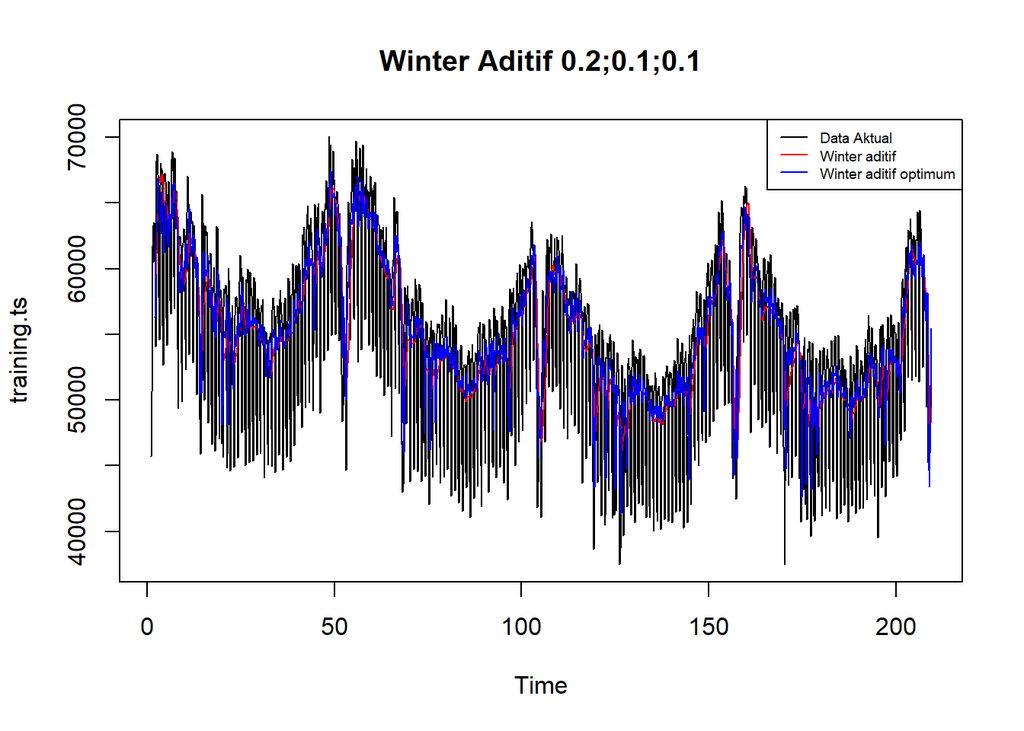

```r
#Plot time series
plot(training.ts, main = "Winter Aditif 0.2;0.1;0.1", type = "l", col = "black")
lines(xhat1, type = "l", col = "red")
lines(xhat1.opt, type = "l", col = "blue")
legend("topright", c("Data Aktual", "Winter aditif", "Winter aditif optimum"),
       cex = 0.6, col = c("black", "red", "blue"), lty = 1)
```

#### Akurasi Data Latih

```r
#Akurasi data training
SSE1 <- winter1$SSE
MSE1 <- winter1$SSE / length(training.ts)
RMSE1 <- sqrt(MSE1)
akurasi1 <- matrix(c(SSE1, MSE1, RMSE1))
row.names(akurasi1) <- c("SSE", "MSE", "RMSE")
colnames(akurasi1) <- c("Akurasi")
akurasi1
```

```
##           Akurasi
## SSE  9.520785e+09
## MSE  6.521086e+06
## RMSE 2.553642e+03
```

```r
SSE1.opt <- winter1.opt$SSE
MSE1.opt <- winter1.opt$SSE / length(training.ts)
RMSE1.opt <- sqrt(MSE1.opt)
akurasi1.opt <- matrix(c(SSE1.opt, MSE1.opt, RMSE1.opt))
row.names(akurasi1.opt) <- c("SSE1.opt", "MSE1.opt", "RMSE1.opt")
colnames(akurasi1.opt) <- c("Akurasi")
akurasi1.opt
```

```
##                Akurasi
## SSE1.opt  6.901653e+09
## MSE1.opt  4.727160e+06
## RMSE1.opt 2.174203e+03
```

```r
akurasi1.train <- data.frame(
  Model_Winter = c("Winter 1", "Winter1 optimal"),
  Nilai_SSE = c(SSE1, SSE1.opt),
  Nilai_MSE = c(MSE1, MSE1.opt),
  Nilai_RMSE = c(RMSE1, RMSE1.opt))
akurasi1.train
```

```
##      Model_Winter  Nilai_SSE Nilai_MSE Nilai_RMSE
## 1        Winter 1 9520785432   6521086   2553.642
## 2 Winter1 optimal 6901653358   4727160   2174.203
```

#### Akurasi Data Uji

```r
#Akurasi Data Testing
selisih1 <- as.numeric(forecast1) - as.numeric(testing.ts)
SSEtesting1 <- sum(selisih1^2)
MSEtesting1 <- SSEtesting1 / length(testing.ts)

selisih1.opt <- as.numeric(forecast1.opt) - as.numeric(testing.ts)
SSEtesting1.opt <- sum(selisih1.opt^2)
MSEtesting1.opt <- SSEtesting1.opt / length(testing.ts)
```

```r
akurasi_testing <- data.frame(
  Model = c("Model1", "Model Optimum"),
  SSE   = c(SSEtesting1, SSEtesting1.opt),
  MSE   = c(MSEtesting1, MSEtesting1.opt)
)

akurasi_testing
```

```
##           Model          SSE         MSE
## 1        Model1 4.299905e+12 11748373091
## 2 Model Optimum 1.750913e+10    47839142
```

### Winter Multiplikatif

Model multiplikatif digunakan jika plot data asli menunjukkan fluktuasi musiman yang berubah sebanding dengan aras data.

#### Pemulusan

```r
#Pemulusan dengan winter multiplikatif
winter2 <- HoltWinters(training.ts, alpha = 0.2, beta = 0.1, gamma = 0.3,
                       seasonal = "multiplicative")
head(winter2$fitted)
```

```
## Time Series:
## Start = c(2, 1)
## End = c(2, 6)
## Frequency = 7
##              xhat    level     trend    season
## 2.000000 58561.54 56307.42  937.9828 1.0229911
## 2.142857 52767.02 58028.60 1016.3018 0.8936762
## 2.285714 51999.86 59616.78 1073.4903 0.8568071
## 2.428571 67460.41 61168.04 1121.2673 1.0830175
## 2.571429 68377.84 62423.46 1134.6818 1.0758314
## 2.714286 65553.47 63577.65 1136.6329 1.0129676
```

```r
xhat2 <- winter2$fitted[, 2]

winter2.opt <- HoltWinters(training.ts, alpha = NULL, beta = NULL, gamma = NULL,
                           seasonal = "multiplicative")
winter2.opt
```

```
## Holt-Winters exponential smoothing with trend and multiplicative seasonal component.
##
## Call:
## HoltWinters(x = training.ts, alpha = NULL, beta = NULL, gamma = NULL,     seasonal = "multiplicative")
##
## Smoothing parameters:
##  alpha: 0.6638761
##  beta : 0.01261295
##  gamma: 0.1577067
##
## Coefficients:
##             [,1]
## a  53923.4246255
## b    -13.9241034
## s1     1.0244785
## s2     1.0370648
## s3     1.0307966
## s4     1.0183683
## s5     0.8931672
## s6     0.8429276
## s7     1.0073240
```

```r
xhat2.opt <- winter2.opt$fitted[, 2]
```

#### Peramalan

```r
#Forecast
forecast2 <- predict(winter2, n.ahead = length(testing.ts))
forecast2.opt <- predict(winter2.opt, n.ahead = length(testing.ts))
```

#### Plot Deret Waktu

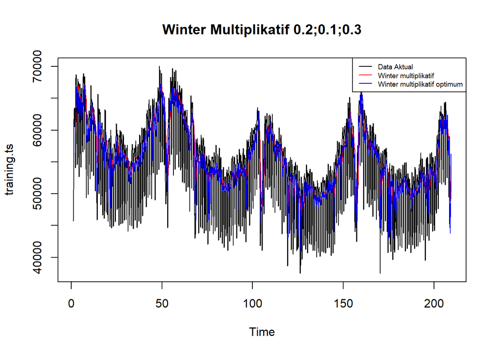

```r
#Plot time series
plot(training.ts, main = "Winter Multiplikatif 0.2;0.1;0.3", type = "l", col = "black")
lines(xhat2, type = "l", col = "red")
lines(xhat2.opt, type = "l", col = "blue")
legend("topright", c("Data Aktual", "Winter multiplikatif", "Winter multiplikatif optimum"),
       cex = 0.6, col = c("black", "red", "blue"), lty = 1)
```

#### Akurasi Data Latih

```r
#Akurasi data training
SSE2 <- winter2$SSE
MSE2 <- winter2$SSE / length(training.ts)
RMSE2 <- sqrt(MSE2)
akurasi2 <- matrix(c(SSE2, MSE2, RMSE2))
row.names(akurasi2) <- c("SSE", "MSE", "RMSE")
colnames(akurasi2) <- c("Akurasi")
akurasi2
```

```
##           Akurasi
## SSE  9.884511e+09
## MSE  6.770213e+06
## RMSE 2.601963e+03
```

```r
SSE2.opt <- winter2.opt$SSE
MSE2.opt <- winter2.opt$SSE / length(training.ts)
RMSE2.opt <- sqrt(MSE2.opt)
akurasi2.opt <- matrix(c(SSE2.opt, MSE2.opt, RMSE2.opt))
row.names(akurasi2.opt) <- c("SSE2.opt", "MSE2.opt", "RMSE2.opt")
colnames(akurasi2.opt) <- c("Akurasi")
akurasi2.opt
```

```
##                Akurasi
## SSE2.opt  6.969083e+09
## MSE2.opt  4.773345e+06
## RMSE2.opt 2.184799e+03
```

```r
akurasi2.train <- data.frame(
  Model_Winter = c("Winter 2", "Winter2 optimal"),
  Nilai_SSE = c(SSE2, SSE2.opt),
  Nilai_MSE = c(MSE2, MSE2.opt),
  Nilai_RMSE = c(RMSE2, RMSE2.opt))
akurasi2.train
```

```
##      Model_Winter  Nilai_SSE Nilai_MSE Nilai_RMSE
## 1        Winter 2 9884511255   6770213   2601.963
## 2 Winter2 optimal 6969083407   4773345   2184.799
```

#### Akurasi Data Uji

```r
selisih2 <- as.numeric(forecast2) - as.numeric(testing.ts)
SSEtesting2 <- sum(selisih2^2)
MSEtesting2 <- SSEtesting2 / length(testing.ts)

selisih2.opt <- as.numeric(forecast2.opt) - as.numeric(testing.ts)
SSEtesting2.opt <- sum(selisih2.opt^2)
MSEtesting2.opt <- SSEtesting2.opt / length(testing.ts)
```

```r
# Atau rapikan dalam tabel
akurasi_testing2 <- data.frame(
  Model = c("Model2", "Model2 Optimal"),
  SSE   = c(SSEtesting2, SSEtesting2.opt),
  MSE   = c(MSEtesting2, MSEtesting2.opt)
)

akurasi_testing2
```

```
##            Model          SSE         MSE
## 1         Model2 3.788171e+12 10350195286
## 2 Model2 Optimal 1.219015e+10    33306430
```

## Ringkasan Seluruh Metode

Perbandingan akhir seluruh metode pada data uji berdasarkan nilai MAPE.

```r
mape_semua <- data.frame(
  Metode = c("SMA (m=7)", "DMA (m=7)", "SES optimum", "DES optimum",
             "Winter Aditif optimum", "Winter Multiplikatif optimum"),
  MAPE = c(as.numeric(MAPE_test.sma),
           as.numeric(MAPE_test.dma),
           as.numeric(hitung(e3, as.numeric(test.ts))["MAPE"]),
           as.numeric(hitung(ed3, as.numeric(test.ts))["MAPE"]),
           mean(abs(selisih1.opt / as.numeric(testing.ts))) * 100,
           mean(abs(selisih2.opt / as.numeric(testing.ts))) * 100)
)
mape_semua <- mape_semua[order(mape_semua$MAPE), ]
row.names(mape_semua) <- NULL
mape_semua
```

```
##                         Metode       MAPE
## 1 Winter Multiplikatif optimum   7.947148
## 2        Winter Aditif optimum   9.333210
## 3                  SES optimum   9.919048
## 4                    SMA (m=7)  12.538983
## 5                  DES optimum 151.423622
## 6                    DMA (m=7) 218.957373
```

```r
cat("Metode terbaik :", mape_semua$Metode[1], "\n")
```

```
## Metode terbaik : Winter Multiplikatif optimum
```

```r
cat("Nilai MAPE     :", round(mape_semua$MAPE[1], 3), "%\n")
```

```
## Nilai MAPE     : 7.947 %
```

Hasil menunjukkan bahwa metode Holt-Winters memberikan akurasi terbaik pada data beban listrik Jerman. Hal ini sejalan dengan hasil eksplorasi yang memperlihatkan adanya pola musiman mingguan yang kuat, yaitu beban listrik pada akhir pekan jauh lebih rendah dibandingkan hari kerja. Metode SMA, DMA, SES, dan DES tidak memiliki komponen musiman dalam persamaannya sehingga tidak mampu menangkap pola tersebut.